# Question 3

2022-06-07

# Prepare my own data to test newly defined functions

```r
# import all HTSeq-count output files
rawdata <- data.frame(read.table("OVCAR5-shCtrl-1.count.out", stringsAsFactors = F, header = F),
                      read.table("OVCAR5-shCtrl-2.count.out", stringsAsFactors = F, header = F),
                      read.table("OVCAR5-shCtrl-3.count.out", stringsAsFactors = F, header = F),
                      read.table("OVCAR5-shSCD-1.count.out", stringsAsFactors = F, header = F),
                      read.table("OVCAR5-shSCD-2.count.out", stringsAsFactors = F, header = F),
                      read.table("OVCAR5-shSCD-3.count.out", stringsAsFactors = F, header = F))

# check data frame names
names(rawdata)
```

```
##  [1] "V1"   "V2"   "V1.1" "V2.1" "V1.2" "V2.2" "V1.3" "V2.3" "V1.4" "V2.4"
## [11] "V1.5" "V2.5"
```

```r
# check part of the data frame with all samples included
rawdata[1:3, 1:12]
```

```
##          V1 V2      V1.1 V2.1      V1.2 V2.2      V1.3 V2.3      V1.4 V2.4
## 1   5S_rRNA  1   5S_rRNA    0   5S_rRNA    2   5S_rRNA    0   5S_rRNA    0
## 2 5_8S_rRNA  0 5_8S_rRNA    0 5_8S_rRNA    0 5_8S_rRNA    0 5_8S_rRNA    0
## 3       7SK  0       7SK    0       7SK    1       7SK    0       7SK    1
##        V1.5 V2.5
## 1   5S_rRNA    1
## 2 5_8S_rRNA    0
## 3       7SK    0
```

```r
# delete redundant columns
rawdata <- rawdata[ ,-c(3, 5, 7, 9, 11)]
# check part of the data frame with all samples included
rawdata[1:3, 1:7]
```

```
##          V1 V2 V2.1 V2.2 V2.3 V2.4 V2.5
## 1   5S_rRNA  1    0    2    0    0    1
## 2 5_8S_rRNA  0    0    0    0    0    0
## 3       7SK  0    0    1    0    1    0
```

```r
# change column names of the data frame
names(rawdata) <- c("hgnc_symbol", "shCtrl-1", "shCtrl-2", "shCtrl-3", "shSCD-1", "shSCD-2", "shSCD-3")
rawdata[1:3, 1:7]
```

```
##   hgnc_symbol shCtrl-1 shCtrl-2 shCtrl-3 shSCD-1 shSCD-2 shSCD-3
## 1     5S_rRNA        1        0        2       0       0       1
## 2   5_8S_rRNA        0        0        0       0       0       0
## 3         7SK        0        0        1       0       1       0
```

```r
# add group names and set group factors
group <- factor(c(rep("shCtrl", 3), rep("shSCD", 3)), levels = c("shCtrl", "shSCD"))
group
```

```
## [1] shCtrl shCtrl shCtrl shSCD  shSCD  shSCD
## Levels: shCtrl shSCD
```

```r
# build DGEList
library("edgeR")
y <- DGEList(counts = rawdata[ ,2:7], genes = rawdata[ ,1], group = group)
y$samples
```

```
##           group lib.size norm.factors
## shCtrl-1 shCtrl 25355035            1
## shCtrl-2 shCtrl 15537816            1
## shCtrl-3 shCtrl 22934708            1
## shSCD-1   shSCD 22064772            1
## shSCD-2   shSCD 14264288            1
## shSCD-3   shSCD 22756601            1
```

```r
# pre-filtering
# As a rule of thumb, genes are dropped if they can't possibly be expressed in all the samples for any of the conditions.
# Usually a gene is required to have a count of 5-10 in a library to be considered expressed in that library.
# Users should also filter with count-per-million (CPM) rather than fltering on the counts directly, as the latter does not account for differences in library sizes between samples.
keep <- rowSums(cpm(y)>1) >= 2
y <- y[keep, , keep.lib.sizes = F]
# TMM normalization
y <- calcNormFactors(y, method = "TMM")
y$samples
```

```
##           group lib.size norm.factors
## shCtrl-1 shCtrl 25288936    1.0087937
## shCtrl-2 shCtrl 15498579    0.9937449
## shCtrl-3 shCtrl 22881240    0.9884407
## shSCD-1   shSCD 22011235    1.0239969
## shSCD-2   shSCD 14234353    0.9749764
## shSCD-3   shSCD 22703172    1.0108329
```

```r
# estimate dispersion
y <- estimateDisp(y, robust = T)
```

```
## Using classic mode.
```

```r
y$common.dispersion
```

```
## [1] 0.01215461
```

```r
# testing for differential expression genes with single factor
et <- exactTest(y, pair = c("shCtrl", "shSCD"))
```

# 1) Principal Component Analysis in edgeR

## Create new function to perform Principal Component Analysis using edgeR class DGEList

Find source code for plotPCA in DESeq2 and adapt the code to format in edgeR https://github.com/mikelove/DESeq2/blob/master/R/plots.R

```r
plotPCA.CPM <- function(object, intgroup = "group", ntop = 500, returnData = F)
{
  # calculate the variance for each gene
  rv <- matrixStats::rowVars(cpm(object))

  # select the ntop genes by variance
  select <- order(rv, decreasing = T)[seq_len(min(ntop, length(rv)))]

  # perform a PCA on the data in cpm(object) for the selected genes
  pca <- prcomp(t(cpm(object)[select, ]))

  # the contribution to the total variance for each component
  percentVar <- pca$sdev^2 / sum(pca$sdev^2)

  if (!all(intgroup %in% names(object$samples))) {
    stop("the argument 'intgroup' should specify columns of names(y$counts)")
  }

  intgroup.df <- as.data.frame(object$samples[, intgroup, drop = F])

  # add the intgroup factors together to create a new grouping factor
  group <- if (length(intgroup) > 1) {
    factor(apply( intgroup.df, 1, paste, collapse = ":"))
  } else {
    object$samples[[intgroup]]
  }

  # assembly the data for the plot
  d <- data.frame(PC1 = pca$x[ , 1], PC2 = pca$x[ , 2], group = group, intgroup.df, name = colnames(object))

  if (returnData) {
    attr(d, "percentVar") <- percentVar[1:2]
    return(d)
  }

  ggplot2::ggplot(data = d, ggplot2::aes_string(x = "PC1", y = "PC2", color = "group")) + ggplot2::geom_point(size = 3) +
    ggplot2::xlab(paste0("PC1: ", round(percentVar[1] * 100),"% variance")) +
      ggplot2::ylab(paste0("PC2: ", round(percentVar[2] * 100),"% variance")) +
        ggplot2::coord_fixed()
}
# setMethod("plotPCA.CPM", signature(object = "DGEList"), plotPCA.CPM)
```

## Generate PCA plot

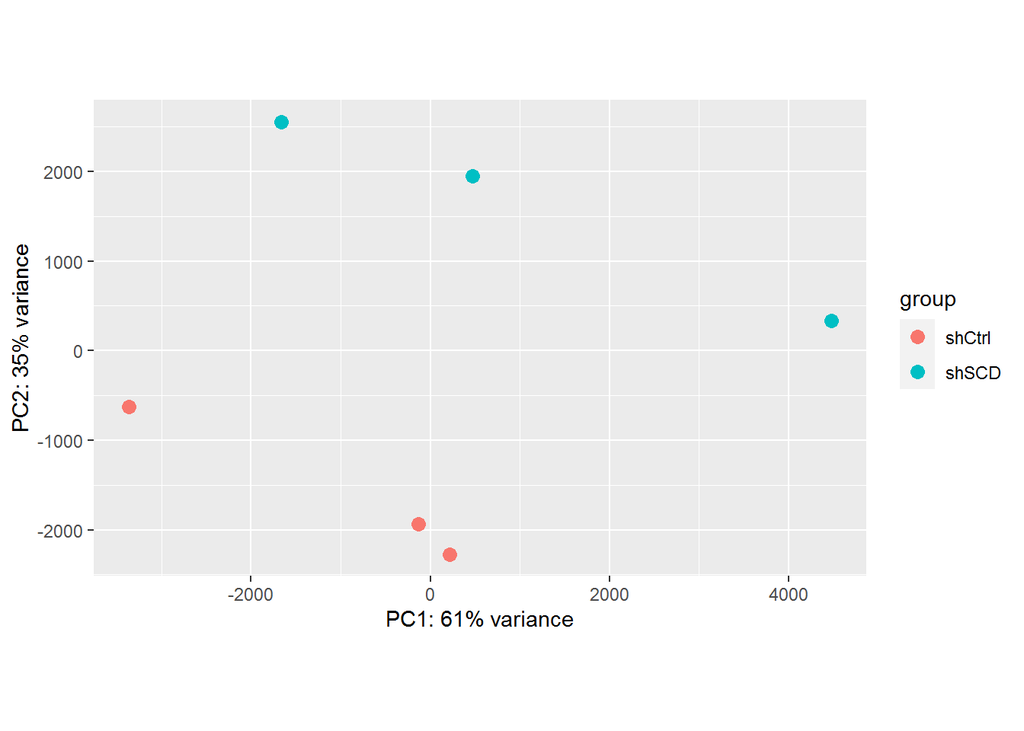

```r
plotPCA.CPM(y)
```

## compare with plotMDS from edgeR

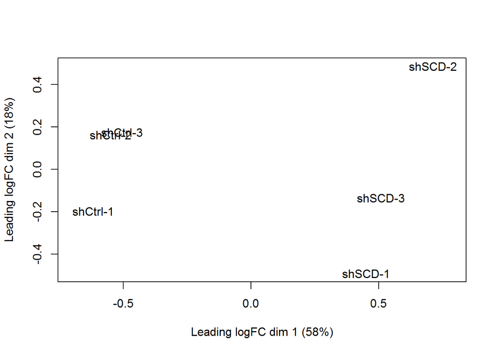

```r
plotMDS(y)
```

# 2) Complete significant gene list in edgeR

## Create new topTags function to output normalized raw counts together with log2 Fold Change, p value, q value, etc.

Find source code for topTags in edgeR https://rdrr.io/bioc/edgeR/src/R/topTags.R

```r
topTags_complete <- function(object, DGEList, n = 10L, adjust.method = "BH", sort.by = "PValue", p.value = 1)
#   Summary table of the n most differentially expressed tags
#   Mark Robinson, Davis McCarthy, Gordon Smyth, Yunshun Chen.
#   Created September 2008.  Last modified 9 Oct 2017.
{
#   Check object
    if(is.null(object$table)) stop("Need to run exactTest or glmLRT first")
    if(is(object,"DGEExact")) test <- "exact" else test <- "glm"
    MultipleContrasts <- (test=="glm" && ncol(object$table) > 4)

# Check DGEList (from "estimateDisp" function source code)
    temp <- as.matrix(DGEList)
    ntags <- nrow(temp)
    if(ntags==0) return(list(span = span, prior.df = prior.df, prior.n = prior.n))
    nlibs <- ncol(temp)

#   Check n
    n <- min(n, nrow(object$table))
    if(n < 1L) stop("No rows to output")

#   Check adjust.method
    FWER.methods <- c("holm", "hochberg", "hommel", "bonferroni")
    FDR.methods <- c("BH", "BY", "fdr")
    adjust.method <- match.arg(adjust.method, c(FWER.methods, FDR.methods, "none"))

#   Check sort.by
    sort.by <- match.arg(sort.by,c("none", "p.value", "PValue", "logFC"))
    if(sort.by == "p.value") sort.by <- "PValue"

#   Absolute log fold change
    if(MultipleContrasts) {
        if(sort.by == "logFC") warning("Two or more logFC columns in DGELRT object. First logFC column used to rank by logFC.")
        alfc <- abs(object$table[ , 1])
    } else {
        alfc <- abs(object$table$logFC)
    }

#   Choose top genes
    o <- switch(sort.by,
        "logFC" = order(alfc, decreasing = T),
        "PValue" = order(object$table$PValue, -alfc),
        "none" = 1:nrow(object$table)
    )
    tab <- object$table[o, ]

#   Add adjusted p-values if appropriate
    adj.p.val <- p.adjust(object$table$PValue, method = adjust.method)
    if(adjust.method != "none") {
        if(adjust.method %in% FWER.methods) adjustment <- "FWER"
        if(adjust.method %in% FDR.methods) adjustment <- "FDR"
        tab[[adjustment]] <- adj.p.val[o]
    }

#   Add gene annotation if appropriate
    if(!is.null(object$genes)){
        if(is.null(dim(object$genes))) object$genes <- data.frame(ID = object$genes, stringsAsFactors = F)
        rn <- row.names(tab)
        tab <- cbind(object$genes[o, ,drop = F], tab)
        row.names(tab) <- rn
    }

#   Thin out fit p.value threshold
    if(p.value < 1) {
        sig <- adj.p.val[o] <= p.value
        sig[is.na(sig)] <- FALSE
        tab <- tab[sig, ]
    }

# Add normalized raw counts
    tab <- data.frame(tab, cpm(DGEList)[rownames(tab), ])

#   Enough rows left?
    if(nrow(tab) < n) n <- nrow(tab)
    if(n < 1L) return(data.frame())

#   Output object
    new("TopTags",list(
        table = tab[1:n, ],
        adjust.method = adjust.method,
        comparison = as.character(object$comparison),
        test = test
    ))
}
```

## Top 10 differential expression genes

```r
topTags_complete(object = et, DGEList = y)
```

```
## Comparison of groups:  shSCD-shCtrl
##         genes     logFC     logCPM       PValue          FDR     shCtrl.1
## 39347   NUPR1  3.242788  2.3357189 9.197442e-53 1.329766e-48    0.9015606
## 53568   TRIB3  1.872519  6.3065442 1.854461e-47 1.340590e-43   31.7114141
## 48889     SCD -1.590790 11.0964840 3.636753e-44 1.752673e-40 3225.4702350
## 28541 GUCY1A3 -2.290686  3.1135320 7.789596e-44 2.815549e-40   14.8953490
## 24401   DDIT3  1.834760  3.9437281 2.984213e-39 8.629152e-36    6.5461139
## 23502    CPA4  1.751402  5.2824758 4.733604e-39 1.140641e-35   16.1496942
## 31309 KLHDC7B  5.559693  0.4297183 1.856229e-36 3.833909e-33    0.0000000
## 54517   UPK3B  1.703354  5.8787740 1.042859e-33 1.884707e-30   24.8909122
## 52169    TCN1 -1.755507  4.5685022 1.724025e-33 2.769551e-30   39.3942783
## 22773   CGNL1 -1.739379  5.0499413 2.117035e-33 3.060809e-30   53.5840582
##           shCtrl.2     shCtrl.3     shSCD.1     shSCD.2     shSCD.3
## 39347    0.7142100 1.193805e+00    7.808536   10.376017    9.324979
## 53568   34.4768634 3.572573e+01  113.268137  137.049887  122.967715
## 48889 3287.2488034 3.349862e+03 1035.074674 1094.525647 1144.662969
## 28541   14.4789840 1.299922e+01    2.706368    2.521948    3.311675
## 24401    6.8823870 6.764898e+00   24.756608   23.057815   24.053217
## 23502   19.0239566 1.839345e+01   54.127351   64.417770   61.571007
## 31309    0.1298564 4.421502e-02    2.573268    2.594004    2.396607
## 54517   29.2826090 2.887241e+01   76.843092  102.607276   90.940333
## 52169   35.1261451 3.448771e+01   12.600137    9.655460    9.891450
## 22773   50.5141237 4.815015e+01   17.125539   11.961241   16.166202
```

## compare with topTags from edgeR

```r
topTags(object = et)
```

```
## Comparison of groups:  shSCD-shCtrl
##         genes     logFC     logCPM       PValue          FDR
## 39347   NUPR1  3.242788  2.3357189 9.197442e-53 1.329766e-48
## 53568   TRIB3  1.872519  6.3065442 1.854461e-47 1.340590e-43
## 48889     SCD -1.590790 11.0964840 3.636753e-44 1.752673e-40
## 28541 GUCY1A3 -2.290686  3.1135320 7.789596e-44 2.815549e-40
## 24401   DDIT3  1.834760  3.9437281 2.984213e-39 8.629152e-36
## 23502    CPA4  1.751402  5.2824758 4.733604e-39 1.140641e-35
## 31309 KLHDC7B  5.559693  0.4297183 1.856229e-36 3.833909e-33
## 54517   UPK3B  1.703354  5.8787740 1.042859e-33 1.884707e-30
## 52169    TCN1 -1.755507  4.5685022 1.724025e-33 2.769551e-30
## 22773   CGNL1 -1.739379  5.0499413 2.117035e-33 3.060809e-30
```

#### The two data frames possess the same gene entries but with the new function output the counts per million for each sample so that people without bioinformatics experience see the table they can immediately examine the data more closely. Additionally, with normalized counts readers can check if the analysis is done correctly in terms of the direction of the fold change (sign of log2 fold change).

#### The output was also verified by another method which exported all significant genes for review and submission of my manuscript.